# Handout-Introduction to R and RStudio

Jacob Thoma

## On Your Own

In the previous few pages, you recreated some of the displays and preliminary analysis of Arbuthnot’s baptism data. Your assignment involves repeating these steps, but for present day birth records in the United States. Load up the present day data with the following command.

```r
source("http://www.openintro.org/stat/data/present.R")
```

The data are stored in a data frame called `present`.

1. What years are included in this data set? What are the dimensions of the data frame and what are the variable or column names?

   *Answer: The data includes years 1940 - 2002. The dimensions of th data frame are 63 rows x 3 columns. The column names are ‘year’, ‘boys’, and ‘girls’.*

```r
source("http://www.openintro.org/stat/data/present.R")

range(present$year)
```

```
## [1] 1940 2002
```

```r
dim(present)
```

```
## [1] 63  3
```

```r
names(present)
```

```
## [1] "year"  "boys"  "girls"
```

2. How do these counts compare to Arbuthnot’s? Are they on a similar scale?

   *Answer: The present day data and Arbuthnot’s data are comparable, they have the same 3 variables but Arbuthnot’s data has records for 19 more years.*

```r
source("http://www.openintro.org/stat/data/present.R")
source("http://www.openintro.org/stat/data/arbuthnot.R")
dim(present)
```

```
## [1] 63  3
```

```r
dim(arbuthnot)
```

```
## [1] 82  3
```

```r
range(arbuthnot$year)
```

```
## [1] 1629 1710
```

3. Make a plot that displays the boy-to-girl ratio for every year in the data set. What do you see? Does Arbuthnot’s observation about boys being born in greater proportion than girls hold up in the U.S.? Include the plot in your response.

   *Answer: Arbuthnot’s observation about boys being born in greater proportion than girls seems to hold up in the U.S. even several centuries later.*

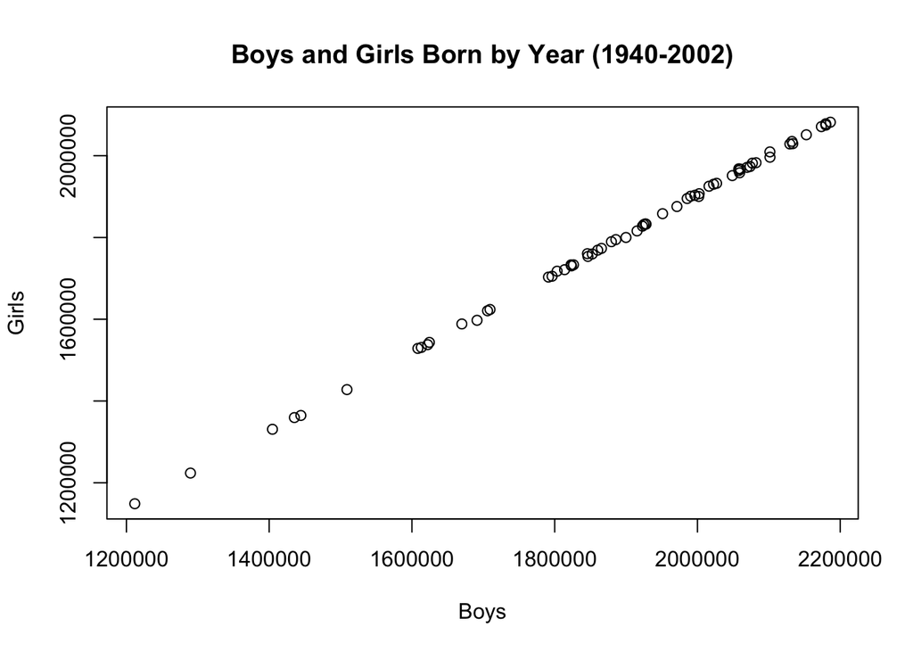

```r
source("http://www.openintro.org/stat/data/present.R")
plot(x = present$boys, y = present$girls, type = 'p', main = "Boys and Girls Born by Year (1940-2002)",
     xlab = 'Boys', ylab = 'Girls')
```

4. In what year did we see the most total number of births in the U.S.? You can refer to the help files or the R reference card http://cran.r-project.org/doc/contrib/Short-refcard.pdf to find helpful commands.

   *Answer: There were the most births in 1961. There were 4,268,326 births.*

```r
source("http://www.openintro.org/stat/data/present.R")
present$Totals = present$boys + present$girls
maxBirths <- max(present$Totals)
present$year[present$Totals == maxBirths]
```

```
## [1] 1961
```

These data come from a report by the Centers for Disease Control http://www.cdc.gov/nchs/data/nvsr/nvsr53/nvsr53_20.pdf. Check it out if you would like to read more about an analysis of sex ratios at birth in the United States.

That was a short introduction to R and RStudio, but we will provide you with more functions and a more complete sense of the language as the course progresses. Feel free to browse around the websites for [R](http://www.r-project.org) and [RStudio](http://rstudio.org) if you’re interested in learning more, or find more labs for practice at http://openintro.org.